# The Relationship Between Study Habits and Productivity

ming mo

# Introduction

University students often experience major changes in productivity depending on study duration, sleep quality, motivation, and study environments. This project explores how daily study habits may influence productivity over time.

The data was collected using a Google Form designed for observational logging. The project focused on recording study duration, subjects studied, productivity levels, mood before studying, gaming habits, sleep hours, and study locations.

The purpose of this visual data story is to identify patterns between study behaviours and productivity. By tracking these observations over multiple days, it becomes easier to understand which habits may contribute to higher levels of productivity.

# Study Duration and Productivity

[figure not shown]

Scatterplot showing study duration and productivity levels

# Most Frequently Studied Subjects

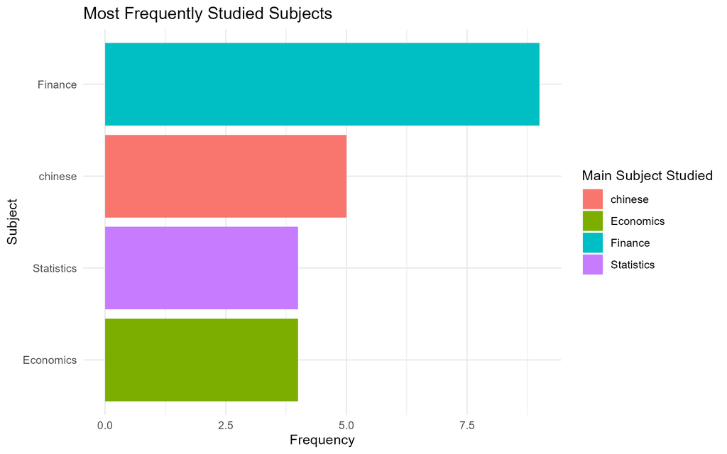

Bar chart showing the frequency of subjects studied

This bar chart compares the frequency of subjects studied throughout the observation period.

Finance appeared most frequently, suggesting that it was the primary academic focus during the data collection period. Other subjects such as Economics and Statistics were also studied regularly.

# Productivity Trends Over Time

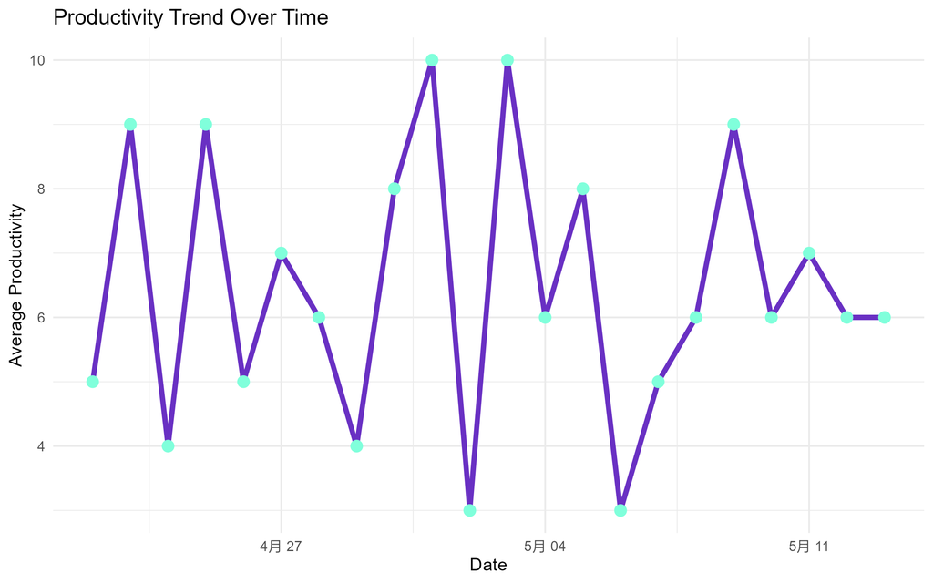

Line chart showing productivity trends over time

This line graph visualises changes in productivity over time.

Several fluctuations can be seen throughout the observation period. Some days showed strong productivity levels, while others were lower.

# Conclusion

Overall, the data suggests that study duration, motivation, and lifestyle factors may influence productivity levels.

This project demonstrates how observational data and visual communication techniques can be combined to create meaningful insights from everyday activities.